# On the waning of forms - a corpus-based analysis of losers in language change (Part 3)

Martin Schweinberger

2021-05-17

[figure not shown]

This document documents the analysis of the adjective amplifier *very* in New Zealand English. The analysis was performed with the aim of fitting a generalized-linear binomial logistic mixed-effects regression to explain which factors correlate with the use of *very* and to ascertain if

1. *very* is decreasing across apparent time
2. if the decrease of *very* is systematic or layered (which would imply that the use of very is stratified along linguistic and social lines) or unsystematic (which would imply that it correlates with few if any linguistic or social variables).

# 1 Introduction

We will now begin with the analysis. In a first step, the session is prepared by setting options and activating packages.

```r
# load packages
library(tidyverse)
library(tidyr)
# set options
options(stringsAsFactors = F)
options(scipen = 999)
options(max.print=10000)
```

We proceed by loading the data, factorizing variables that are so far represented as character strings instead of factors, and inspecting its characteristics.

```r
# load data
verywsc <- read.delim(here::here("data", "ampwsc_regdat.txt"), sep = "\t", header = T, skipNul = T)
# remove superfluous variables
verywsc <- verywsc %>%
  dplyr::filter(Variant != "0") %>%
  dplyr::select(-ID, -FileSpeaker, -Speaker, -File, -Age_original, -Variant) %>%
  # convert to title format
  dplyr::mutate(Ethnicity = stringr::str_to_title(Ethnicity),
                L1 = stringr::str_to_title(L1),
                Emotionality = stringr::str_to_title(Emotionality)) %>%
  # convert charaters to factors
  dplyr::mutate_if(is.character, factor)
# inspect data
nrow(verywsc); str(verywsc); head(verywsc); summary (verywsc)
```

```
## [1] 2344
```

```
## 'data.frame':    2344 obs. of  14 variables:
##  $ Adjective       : Factor w/ 420 levels "able","absurd",..: 158 87 87 147 127 247 82 308 295 391 ...
##  $ Ethnicity       : Factor w/ 4 levels "Maori","Maori/Pakeha",..: 4 4 4 4 4 4 4 4 4 4 ...
##  $ Gender          : Factor w/ 2 levels "Man","Woman": 2 2 2 2 1 1 1 1 1 1 ...
##  $ Age             : Factor w/ 6 levels "16-19","20-29",..: 4 4 4 4 2 2 2 2 2 2 ...
##  $ Education       : Factor w/ 2 levels "NoUniversity",..: 2 2 2 2 1 1 1 1 1 1 ...
##  $ L1              : Factor w/ 2 levels "English","Other": 1 1 1 1 1 1 1 1 1 1 ...
##  $ Type            : Factor w/ 14 levels "BroadcastInterview",..: 9 9 9 9 9 9 9 9 9 9 ...
##  $ Frequency       : num  0.4401 0.0994 0.0994 0.2698 0.0515 ...
##  $ Function        : Factor w/ 2 levels "Attributive",..: 2 1 1 1 2 1 1 2 2 2 ...
##  $ Priming         : Factor w/ 2 levels "NoPrime","Prime": 1 1 1 1 1 1 1 1 1 1 ...
##  $ Gradability     : num  0.13 -3.664 0.639 -2.874 1 ...
##  $ SemanticCategory: Factor w/ 9 levels "Color","Difficulty",..: 2 4 4 4 5 5 4 3 6 4 ...
##  $ Emotionality    : Factor w/ 3 levels "Negative","Neutral",..: 2 1 1 2 3 2 3 2 2 1 ...
##  $ very            : Factor w/ 2 levels "other","very": 1 1 1 2 1 1 1 1 1 2 ...
```

```
##     Adjective Ethnicity Gender   Age    Education      L1          Type
## 1        hard    Pakeha  Woman 40-49   University English RadioTalkback
## 2   desperate    Pakeha  Woman 40-49   University English RadioTalkback
## 3   desperate    Pakeha  Woman 40-49   University English RadioTalkback
## 4       funny    Pakeha  Woman 40-49   University English RadioTalkback
## 5 fascinating    Pakeha    Man 20-29 NoUniversity English RadioTalkback
## 6  outrageous    Pakeha    Man 20-29 NoUniversity English RadioTalkback
##   Frequency    Function Priming Gradability SemanticCategory Emotionality  very
## 1   0.44015 Predicative NoPrime   0.1299883       Difficulty      Neutral other
## 2   0.09939 Attributive NoPrime  -3.6635616  HumanPropensity     Negative other
## 3   0.09939 Attributive NoPrime   0.6389904  HumanPropensity     Negative other
## 4   0.26977 Attributive NoPrime  -2.8740838  HumanPropensity      Neutral  very
## 5   0.05153 Predicative NoPrime   1.0000000            Other     Positive other
## 6   0.10307 Attributive NoPrime  -0.2669646            Other      Neutral other
```

```
##    Adjective           Ethnicity      Gender        Age
##  good   : 417   Maori       : 224   Man  : 929   16-19:340
##  nice   : 137   Maori/Pakeha:  79   Woman:1415   20-29:948
##  hard   :  80   Other       : 219                30-39:320
##  funny  :  77   Pakeha      :1822                40-49:414
##  bad    :  71                                    50-59:208
##  cool   :  54                                    60+  :114
##  (Other):1508
##         Education          L1                            Type
##  NoUniversity:1180   English:2150   Conversation           :1612
##  University  :1164   Other  : 194   TelephoneConversation  : 186
##                                     BroadcastInterview     : 154
##                                     TransactionsAndMeetings: 152
##                                     RadioTalkback          :  55
##                                     SportsCommentary       :  53
##                                     (Other)                : 132
##    Frequency              Function       Priming      Gradability
##  Min.   :0.00943   Attributive:1326   NoPrime:1946   Min.   :-3.6636
##  1st Qu.:0.09471   Predicative:1018   Prime  : 398   1st Qu.:-3.2837
##  Median :0.31969                                     Median :-1.0586
##  Mean   :1.41350                                     Mean   :-1.2369
##  3rd Qu.:1.32536                                     3rd Qu.: 0.5163
##  Max.   :6.89038                                     Max.   : 3.6634
##
##          SemanticCategory   Emotionality     very
##  HumanPropensity :798     Negative: 392   other:1697
##  Value           :762     Neutral :1115   very : 647
##  Other           :241     Positive: 837
##  Difficulty      :179
##  Dimension       :152
##  PhysicalProperty:145
##  (Other)         : 67
```

We will now scale numeric variables so that the estimates refer to the mean of the numeric variables rather than their true 0-point. This is necessary as estimates for adjectives that occur with a frequency of 0 are nonsensical.

```r
# frequency
summary(verywsc$Frequency)
```

```
##    Min. 1st Qu.  Median    Mean 3rd Qu.    Max.
## 0.00943 0.09471 0.31969 1.41350 1.32536 6.89038
```

```r
verywsc <- verywsc %>%
  dplyr::mutate(Frequency  = scale(Frequency)) %>%
  dplyr::mutate(Frequency = as.vector(Frequency))
# inspect
summary(verywsc$Frequency)
```

```
##     Min.  1st Qu.   Median     Mean  3rd Qu.     Max.
## -0.65391 -0.61419 -0.50941  0.00000 -0.04105  2.55070
```

We plot the scaled variable (Frequency).

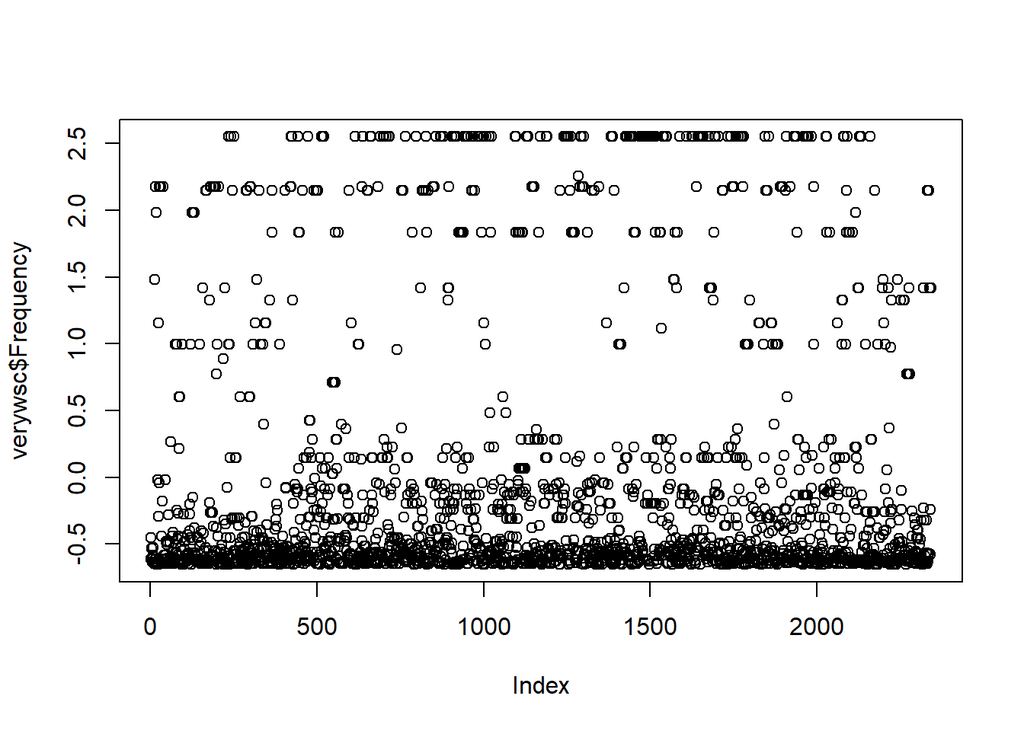

```r
plot(verywsc$Frequency)
```

We also scale gradability and plot the resulting scaled gradability.

```r
# gradability
verywsc <- verywsc %>%
  dplyr::mutate(Gradability  = scale(Gradability-1)) %>%
  dplyr::mutate(Gradability = as.vector(Gradability))
# summarize gradability
summary(verywsc$Gradability)
```

```
##     Min.  1st Qu.   Median     Mean  3rd Qu.     Max.
## -1.34662 -1.13581  0.09892  0.00000  0.97292  2.71932
```

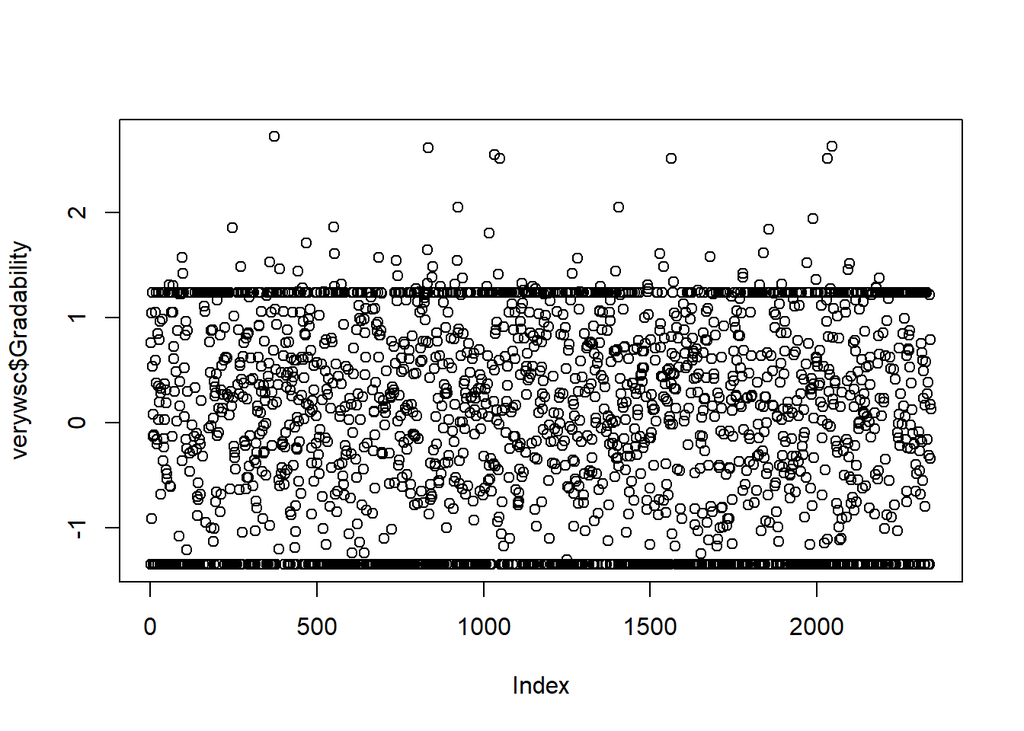

```r
# visualize gradability
plot(verywsc$Gradability)
```

# 2 CIT

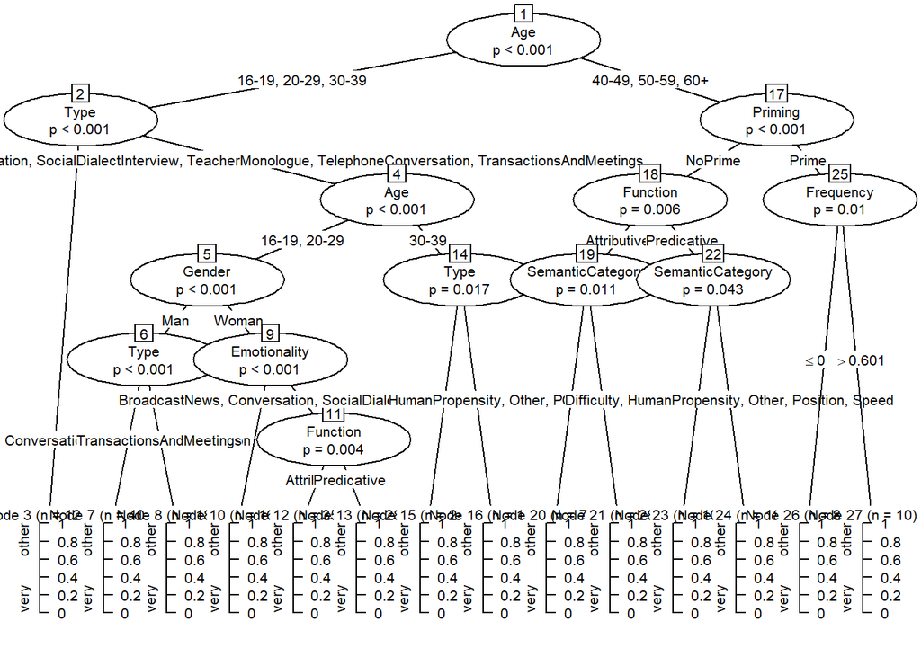

```r
# load packages
library(partykit)
library(tidyverse)
# create data
citdata <- verywsc
# set seed
set.seed(111)
# apply bonferroni correction (1 minus alpha multiplied by n of predictors)
control = ctree_control(mincriterion = 1-(.05*ncol(citdata)-1))
# create initial conditional inference tree model
citd.ctree <- partykit::ctree(very ~ Age +  SemanticCategory + Frequency +  Priming +
                                Type + Emotionality  + Gender + L1 + Function, data = citdata)
plot(citd.ctree, gp = gpar(fontsize = 8)) # plot final ctree
```

```r
citd.ctree
```

```
##
## Model formula:
## very ~ Age + SemanticCategory + Frequency + Priming + Type +
##     Emotionality + Gender + L1 + Function
##
## Fitted party:
## [1] root
## |   [2] Age in 16-19, 20-29, 30-39
## |   |   [3] Type in BroadcastInterview, Lecture, OralHistoryInterview, ParliamentaryDebate, RadioTalkback, SportsCommentary: other (n = 120, err = 49.2%)
## |   |   [4] Type in BroadcastNews, Conversation, SocialDialectInterview, TeacherMonologue, TelephoneConversation, TransactionsAndMeetings
## |   |   |   [5] Age in 16-19, 20-29
## |   |   |   |   [6] Gender in Man
## |   |   |   |   |   [7] Type in Conversation, TelephoneConversation: other (n = 400, err = 14.2%)
## |   |   |   |   |   [8] Type in TransactionsAndMeetings: very (n = 18, err = 33.3%)
## |   |   |   |   [9] Gender in Woman
## |   |   |   |   |   [10] Emotionality in Negative: other (n = 164, err = 0.6%)
## |   |   |   |   |   [11] Emotionality in Neutral, Positive
## |   |   |   |   |   |   [12] Function in Attributive: other (n = 353, err = 14.4%)
## |   |   |   |   |   |   [13] Function in Predicative: other (n = 288, err = 5.9%)
## |   |   |   [14] Age in 30-39
## |   |   |   |   [15] Type in BroadcastNews, Conversation, SocialDialectInterview, TeacherMonologue, TransactionsAndMeetings: other (n = 246, err = 21.1%)
## |   |   |   |   [16] Type in TelephoneConversation: very (n = 19, err = 36.8%)
## |   [17] Age in 40-49, 50-59, 60+
## |   |   [18] Priming in NoPrime
## |   |   |   [19] Function in Attributive
## |   |   |   |   [20] SemanticCategory in Color, Difficulty, Dimension: very (n = 71, err = 25.4%)
## |   |   |   |   [21] SemanticCategory in HumanPropensity, Other, PhysicalProperty, Position, Speed, Value: other (n = 288, err = 49.0%)
## |   |   |   [22] Function in Predicative
## |   |   |   |   [23] SemanticCategory in Color, Dimension, PhysicalProperty, Value: other (n = 105, err = 26.7%)
## |   |   |   |   [24] SemanticCategory in Difficulty, HumanPropensity, Other, Position, Speed: other (n = 182, err = 48.9%)
## |   |   [25] Priming in Prime
## |   |   |   [26] Frequency <= 0.60148: very (n = 80, err = 11.2%)
## |   |   |   [27] Frequency > 0.60148: other (n = 10, err = 40.0%)
##
## Number of inner nodes:    13
## Number of terminal nodes: 14
```

According to the CIT, we can simplify Semantic Category, Type, and Age. However, we will only collapse categories that are conceptually related (collapse Speed, Position, and Dimension as well as Physical Property and Color)

```r
verywsc <- verywsc %>%
  # simplify age
  dplyr::mutate(Age = as.character(Age)) %>%
  dplyr::mutate(Age = dplyr::case_when(Age == "16-19" ~ "16-29",
                                       Age == "20-29" ~ "16-29",
                                       Age == "40-49" ~ "40+",
                                       Age == "50-59" ~ "40+",
                                       Age == "60+" ~ "40+",
                                       TRUE ~ Age)) %>%
  # simplify type
  dplyr::mutate(Type = as.character(Type)) %>%
  dplyr::mutate(Type = dplyr::case_when(Type == "Conversation" ~ "Private",
                                        Type == "TelephoneConversation" ~ "Private",
                                        Type == "BroadcastInterview" ~ "Public",
                                        Type == "Lecture" ~ "Public",
                                        Type == "OralHistoryInterview" ~ "Public",
                                        Type == "ParliamentaryDebate" ~ "Public",
                                        Type == "RadioTalkback" ~ "Public",
                                        Type == "SportsCommentary" ~ "Public",
                                        Type == "BroadcastNews" ~ "Formal",
                                        Type == "SocialDialectInterview" ~ "Formal",
                                        Type == "TeacherMonologue" ~ "Formal",
                                        Type == "TransactionsAndMeetings" ~ "Formal",
                                        Type == "BroadcastMonologue" ~ "Formal",
                                        Type == "BroadcastWeather" ~ "Formal",
                                        TRUE ~ Type)) %>%
  # simplify semantic category
  dplyr::mutate(SemanticCategory = as.character(SemanticCategory)) %>%
  dplyr::mutate(SemanticCategory = dplyr::case_when(SemanticCategory == "Speed" ~ "Dimension",
                                                    SemanticCategory == "Position" ~ "Dimension",
                                                    SemanticCategory == "Color" ~ "PhyProperty",
                                                    SemanticCategory == "PhysicalProperty" ~ "PhyProperty",
                                                    SemanticCategory == "HumanPropensity" ~ "Human",
                                                    TRUE ~ SemanticCategory)) %>%
  # simplify Ethnicity
    dplyr::mutate(Ethnicity = as.character(Ethnicity)) %>%
  dplyr::mutate(Ethnicity = dplyr::case_when(Ethnicity == "Maori/Pakeha" ~ "Other",
                                             TRUE ~ Ethnicity)) %>%
  # round Frequency
  dplyr::mutate(Frequency = round(Frequency, 5)) %>%
  # round Gradability
  dplyr::mutate(Gradability = round(Gradability, 5)) %>%
  # factorize
  dplyr::mutate(Age = factor(Age),
                Type = factor(Type),
                SemanticCategory = factor(SemanticCategory),
                Ethnicity = factor(Ethnicity))
# inspect
table(verywsc$SemanticCategory)
```

```
##
##  Difficulty   Dimension       Human       Other PhyProperty       Value
##         179         191         798         241         173         762
```

```r
table(verywsc$Age)
```

```
##
## 16-29 30-39   40+
##  1288   320   736
```

```r
table(verywsc$Type)
```

```
##
##  Formal Private  Public
##     208    1798     338
```

```r
table(verywsc$Ethnicity)
```

```
##
##  Maori  Other Pakeha
##    224    298   1822
```

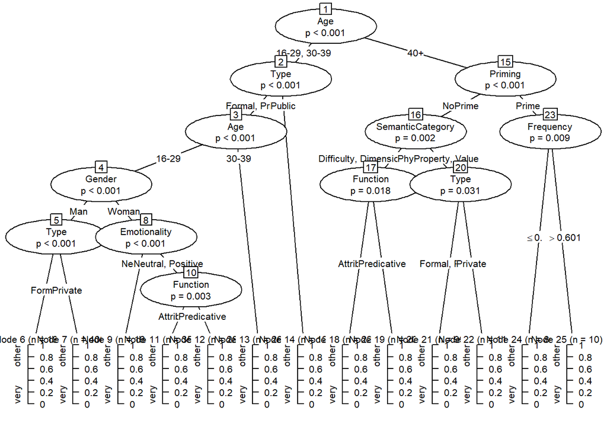

```r
# create data
citdata <- verywsc
# set seed
set.seed(111)
# apply bonferroni correction (1 minus alpha multiplied by n of predictors)
control = ctree_control(mincriterion = 1-(.05*ncol(citdata)-1))
# create initial conditional inference tree model
citd.ctree <- partykit::ctree(very ~ Age +  SemanticCategory + Frequency +  Priming +
                                Type + Emotionality  + Gender + L1 + Function, data = citdata)
plot(citd.ctree, gp = gpar(fontsize = 8)) # plot final ctree
```

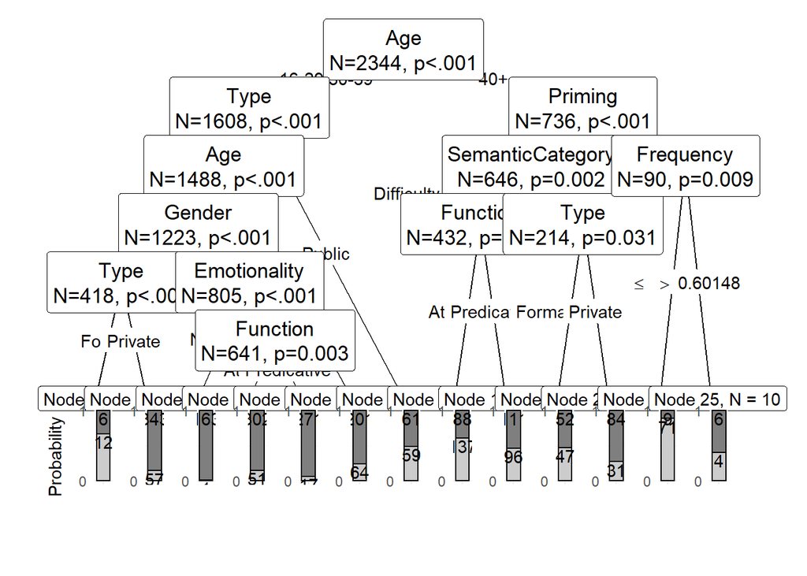

```r
# activate package
library(ggparty)
# extract p-values
pvals <- unlist(nodeapply(citd.ctree, ids = nodeids(citd.ctree), function(n) info_node(n)$p.value))
pvals <- pvals[pvals <.05]
# plotting
ggparty(citd.ctree) +
  geom_edge() +
  geom_edge_label() +
  geom_node_label(line_list = list(aes(label = splitvar),
                                   aes(label = paste0("N=", nodesize, ", p",
                                                      ifelse(pvals < .001, "<.001", paste0("=", round(pvals, 3)))),
                                       size = 13)),
                  line_gpar = list(list(size = 13),
                                   list(size = 13)),
                  ids = "inner") +
  geom_node_label(aes(label = paste0("Node ", id, ", N = ", nodesize)),
    ids = "terminal", nudge_y = -0.0, nudge_x = 0.01) +
  geom_node_plot(gglist = list(
    geom_bar(aes(x = "", fill = very),
             position = position_fill(), color = "black"),
      theme_minimal(),
      scale_fill_manual(values = c("gray50", "gray80"), guide = FALSE),
      scale_y_continuous(breaks = c(0, 1)),
    xlab(""),
    ylab("Probability"),
    geom_text(aes(x = "", group = very,
                  label = stat(count)),
              stat = "count", position = position_fill(), vjust = 1.1)),
    shared_axis_labels = TRUE) +
  ggsave(file =  here::here("images", "Cit_very.png"),
         width = 60, height = 30, units = c("cm"),  dpi = 600)
```

# 3 Boruta

We now begin with the modeling. In a first step, we use a Boruta analysis as a variable selection procedure to determine which variables have any sort of meaningful relationship with the dependent variable. We will only consider variables which have been deemed as being important during the model fitting process.

```r
# load library
library(Boruta)
# create data for boruta
borutadata <- verywsc %>%
  na.omit()
# save and load data
write.table(borutadata, here::here("data", "borutadata.txt"), sep = "\t",
            col.names = T, row.names = F, quote = F)
# run 1
set.seed(2019121201)
boruta1 <- Boruta(very ~.,data=borutadata)
print(boruta1)
```

```
## Boruta performed 99 iterations in 57.58738 secs.
##  12 attributes confirmed important: Adjective, Age, Education,
## Emotionality, Ethnicity and 7 more;
##  No attributes deemed unimportant.
##  1 tentative attributes left: L1;
```

We now begin with the modelling. In a first step, we use a Boruta analysis as a variable selection procedure to determine which variables have any sort of meaningful relationship with the dependent variable.

```r
rejected <- names(boruta1$finalDecision)[which(boruta1$finalDecision == "Rejected")]
# update data for boruta
borutadata <- borutadata %>%
  dplyr::select(-rejected)
```

```
## Note: Using an external vector in selections is ambiguous.
## i Use `all_of(rejected)` instead of `rejected` to silence this message.
## i See <https://tidyselect.r-lib.org/reference/faq-external-vector.html>.
```

```r
# run 2
set.seed(2019121202)
boruta2 <- Boruta(very ~.,data=borutadata)
print(boruta2)
```

```
## Boruta performed 99 iterations in 1.09979 mins.
##  11 attributes confirmed important: Adjective, Age, Education,
## Emotionality, Ethnicity and 6 more;
##  No attributes deemed unimportant.
##  2 tentative attributes left: Gradability, L1;
```

```r
rejected <- names(boruta1$finalDecision)[which(boruta1$finalDecision == "Tentative")]
# update data for boruta
borutadata <- borutadata %>%
  dplyr::select(-rejected)
# run 3
set.seed(2019121203)
boruta3 <- Boruta(very ~., data=borutadata)
print(boruta3)
```

```
## Boruta performed 44 iterations in 27.67078 secs.
##  12 attributes confirmed important: Adjective, Age, Education,
## Emotionality, Ethnicity and 7 more;
##  No attributes deemed unimportant.
```

No more variables need to be removed. We now inspect the visualizations of the Boruta analysis.

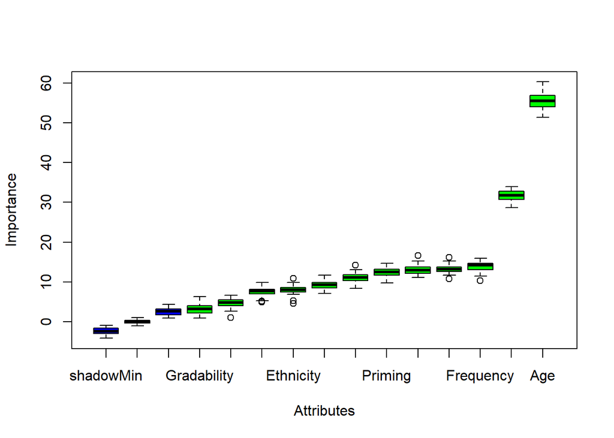

```r
plot(boruta3)
```

In addition, we inspect the history of the Boruta runs.

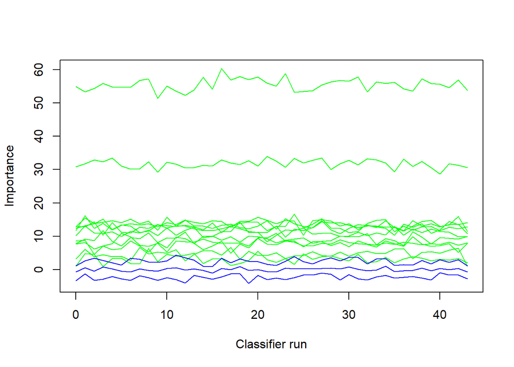

```r
plotImpHistory(boruta3)
```

Now, we create the final publication visualization of the Boruta analysis.

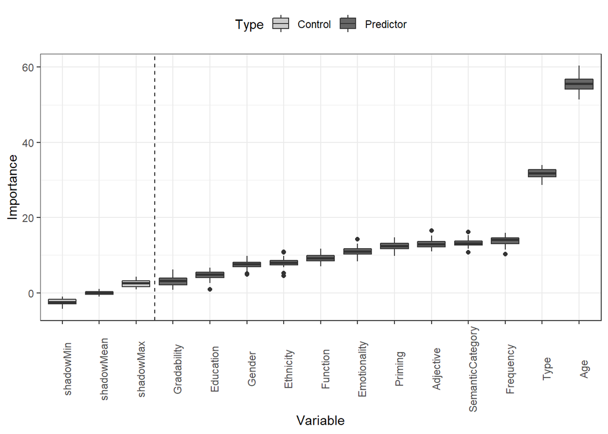

```r
borutadf <- as.data.frame(boruta3$ImpHistory) %>%
  gather(Variable, Importance, Adjective:shadowMin) %>%
  mutate(Type = ifelse(str_detect(Variable, "shadow"), "Control", "Predictor")) %>%
  mutate(Type = factor(Type),
         Variable = factor(Variable))
ggplot(borutadf, aes(x = reorder(Variable, Importance, mean), y = Importance, fill = Type)) +
  geom_boxplot() +
  geom_vline(xintercept=3.5, linetype="dashed", color = "black") +
  scale_fill_manual(values = c("gray80", "gray40")) +
  theme_bw() +
  theme(legend.position = "top",
        axis.text.x = element_text(angle=90)) +
  labs(x = "Variable") +
  ggsave(file =  here::here("images", "Boruta.png"),
         width = 15, height = 10, units = c("cm"),  dpi = 600)
```

Potentially relevant predictors are:

# 4 Mixed-Effects Model

We begin with the model fitting by setting options and creating intercept-only base-line models.

```r
# load library
library(rms)
# set options
options(contrasts  =c("contr.treatment", "contr.poly"))
verywsc.dist <- datadist(verywsc)
options(datadist = "verywsc.dist")
# generate initial minimal regression model
m0.glm = glm(very ~ 1, family = binomial, data = verywsc)
# inspect results
summary(m0.glm)
```

```
##
## Call:
## glm(formula = very ~ 1, family = binomial, data = verywsc)
##
## Deviance Residuals:
##     Min       1Q   Median       3Q      Max
## -0.8037  -0.8037  -0.8037   1.6045   1.6045
##
## Coefficients:
##             Estimate Std. Error z value            Pr(>|z|)
## (Intercept)  -0.9643     0.0462  -20.87 <0.0000000000000002 ***
## ---
## Signif. codes:  0 '***' 0.001 '**' 0.01 '*' 0.05 '.' 0.1 ' ' 1
##
## (Dispersion parameter for binomial family taken to be 1)
##
##     Null deviance: 2762  on 2343  degrees of freedom
## Residual deviance: 2762  on 2343  degrees of freedom
## AIC: 2764
##
## Number of Fisher Scoring iterations: 4
```

In a next step, we create analogous base-line models with Adjective as a random effect (random intercepts).

```r
# load packages
library(lme4)
library(car)
# create model with a random intercept for Adjective
m0.glmer = glmer(very ~ (1|Adjective), data = verywsc, family = binomial)
```

We can now use the AIC to determine if including a random effect structure is justified.

```r
aic.glmer <- AIC(logLik(m0.glmer))
aic.glm <- AIC(logLik(m0.glm))
aic.glmer; aic.glm
```

```
## [1] 2613.174
```

```
## [1] 2763.976
```

The AIC of the glmer object is substantially smaller which indicates that including the random intercepts appears to be justified.

## Model fitting

#### Age

```r
#   manual modelfitting
m0.glmer <- glmer(very ~ 1 + (1|Adjective), family = binomial, data = verywsc,
                  control=glmerControl(optimizer="bobyqa"))
# add Age
ifelse(min(ftable(verywsc$Age, verywsc$very)) == 0, "not possible", "possible")
```

```
## [1] "possible"
```

```r
m1.glmer <- update(m0.glmer, .~.+Age)
anova(m0.glmer, m1.glmer, test = "Chi")
```

```
## Data: verywsc
## Models:
## m0.glmer: very ~ 1 + (1 | Adjective)
## m1.glmer: very ~ (1 | Adjective) + Age
##          npar    AIC    BIC  logLik deviance  Chisq Df            Pr(>Chisq)
## m0.glmer    2 2613.2 2624.7 -1304.6   2609.2
## m1.glmer    4 2338.9 2361.9 -1165.4   2330.9 278.34  2 < 0.00000000000000022
##
## m0.glmer
## m1.glmer ***
## ---
## Signif. codes:  0 '***' 0.001 '**' 0.01 '*' 0.05 '.' 0.1 ' ' 1
```

```r
Anova(m1.glmer, type = "III", test = "Chi")
```

```
## Analysis of Deviance Table (Type III Wald chisquare tests)
##
## Response: very
##              Chisq Df            Pr(>Chisq)
## (Intercept) 276.09  1 < 0.00000000000000022 ***
## Age         255.71  2 < 0.00000000000000022 ***
## ---
## Signif. codes:  0 '***' 0.001 '**' 0.01 '*' 0.05 '.' 0.1 ' ' 1
```

Probability of very among speakers aged 40+

```r
round(plogis(fixef(m1.glmer)[1] + fixef(m1.glmer)[3])*100, 2)
```

```
## (Intercept)
##       50.28
```

We will now check if the sample size is sufficient to detect a medium-sized effect (Cohen’s d 0.5) - the traditional scale is 0.2 for a small, 0.5 for medium-sized, and 0.8 for a large or strong effect.

In order to check what a medium-sized effect is, we need to determine the odds ratios of the fixed effects and then convert them into Cohen’s d values for which we have associations between traditional denominations (small, medium, and large) and effect sife values. According to Chen, Cohen, and Chen (2010) odds ratios of 1.68, 3.47, and 6.71 are equivalent to Cohen’s d = 0.2 (small), 0.5 (medium), and 0.8 (large).

```r
pm1 <- m1.glmer
estimatesfixedeffects <- fixef(pm1)
exp(estimatesfixedeffects)
```

```
## (Intercept)    Age30-39      Age40+
##   0.1367413   2.7162752   7.3956606
```

We will now change the size of the effect of Age40+ to make it “medium-sized”, i.e. on the brink of being noise but being just strong enough to be considered small. In other words, we will set the effect so that its odds ratio is exactly 3.47.

```r
fixef(pm1)["Age40+"] <- 1.244
estimatesfixedeffects <- fixef(pm1)
exp(estimatesfixedeffects)
simr::powerSim(pm1, fixed("Age", "lr"), nsim=100)
```

#### Frequency

```r
# add Frequency
m2.glmer <- update(m1.glmer, .~.+ Frequency)
car::vif(m2.glmer)
```

```
##               GVIF Df GVIF^(1/(2*Df))
## Age       1.130609  2        1.031165
## Frequency 1.130609  1        1.063301
```

```r
anova(m2.glmer, m1.glmer, test = "Chi")
```

```
## Data: verywsc
## Models:
## m1.glmer: very ~ (1 | Adjective) + Age
## m2.glmer: very ~ (1 | Adjective) + Age + Frequency
##          npar    AIC    BIC  logLik deviance  Chisq Df Pr(>Chisq)
## m1.glmer    4 2338.9 2361.9 -1165.4   2330.9
## m2.glmer    5 2340.6 2369.3 -1165.3   2330.6 0.3192  1     0.5721
```

```r
pm2 <- m2.glmer
fixef(pm2)["Frequency"] <- 1.244
estimatesfixedeffects <- fixef(pm2)
simr::powerSim(pm2, fixed("Frequency", "lr"), nsim=100)
```

#### Priming

```r
ifelse(min(ftable(verywsc$Priming, verywsc$very)) == 0, "not possible", "possible")
```

```
## [1] "possible"
```

```r
m3.glmer <- update(m1.glmer, .~.+Priming)
car::vif(m3.glmer)
```

```
##            GVIF Df GVIF^(1/(2*Df))
## Age     1.02818  2        1.006972
## Priming 1.02818  1        1.013992
```

```r
anova(m3.glmer, m1.glmer, test = "Chi")
```

```
## Data: verywsc
## Models:
## m1.glmer: very ~ (1 | Adjective) + Age
## m3.glmer: very ~ (1 | Adjective) + Age + Priming
##          npar    AIC    BIC  logLik deviance  Chisq Df Pr(>Chisq)
## m1.glmer    4 2338.9 2361.9 -1165.4   2330.9
## m3.glmer    5 2330.8 2359.6 -1160.4   2320.8 10.031  1   0.001539 **
## ---
## Signif. codes:  0 '***' 0.001 '**' 0.01 '*' 0.05 '.' 0.1 ' ' 1
```

```r
Anova(m3.glmer, type = "III", test = "Chi")
```

```
## Analysis of Deviance Table (Type III Wald chisquare tests)
##
## Response: very
##               Chisq Df            Pr(>Chisq)
## (Intercept) 282.925  1 < 0.00000000000000022 ***
## Age         261.608  2 < 0.00000000000000022 ***
## Priming      10.248  1              0.001368 **
## ---
## Signif. codes:  0 '***' 0.001 '**' 0.01 '*' 0.05 '.' 0.1 ' ' 1
```

```r
pm3 <- m3.glmer
fixef(pm3)["PrimingPrime"] <- 1.244
estimatesfixedeffects <- fixef(pm3)
pm3_results <- simr::powerSim(pm3, fixed("PrimingPrime", "z"), nsim=100)
pm3_results
```

#### Emotionality

```r
ifelse(min(ftable(verywsc$Emotionality, verywsc$very)) == 0, "not possible", "possible")
```

```
## [1] "possible"
```

```r
m4.glmer <- update(m3.glmer, .~.+Emotionality)
car::vif(m4.glmer)
```

```
##                  GVIF Df GVIF^(1/(2*Df))
## Age          1.029318  2        1.007250
## Priming      1.028770  1        1.014283
## Emotionality 1.000886  2        1.000221
```

```r
anova(m4.glmer, m3.glmer, test = "Chi")
```

```
## Data: verywsc
## Models:
## m3.glmer: very ~ (1 | Adjective) + Age + Priming
## m4.glmer: very ~ (1 | Adjective) + Age + Priming + Emotionality
##          npar    AIC    BIC  logLik deviance  Chisq Df Pr(>Chisq)
## m3.glmer    5 2330.8 2359.6 -1160.4   2320.8
## m4.glmer    7 2317.9 2358.2 -1151.9   2303.9 16.979  2  0.0002056 ***
## ---
## Signif. codes:  0 '***' 0.001 '**' 0.01 '*' 0.05 '.' 0.1 ' ' 1
```

```r
Anova(m4.glmer, type = "III", test = "Chi")
```

```
## Analysis of Deviance Table (Type III Wald chisquare tests)
##
## Response: very
##                Chisq Df            Pr(>Chisq)
## (Intercept)  152.230  1 < 0.00000000000000022 ***
## Age          256.790  2 < 0.00000000000000022 ***
## Priming       10.525  1             0.0011777 **
## Emotionality  16.084  2             0.0003217 ***
## ---
## Signif. codes:  0 '***' 0.001 '**' 0.01 '*' 0.05 '.' 0.1 ' ' 1
```

```r
pm4 <- m4.glmer
fixef(pm4)["EmotionalityPositive"] <- 1.244 # positive because it has fewer observations
estimatesfixedeffects <- fixef(pm4)
pm3_results <- simr::powerSim(pm4, fixed("EmotionalityPositive", "z"), nsim=100)
pm3_results
```

#### Type

```r
ifelse(min(ftable(verywsc$Type, verywsc$very)) == 0, "not possible", "possible")
```

```
## [1] "possible"
```

```r
m5.glmer <- update(m4.glmer, .~.+Type)
car::vif(m5.glmer)
```

```
##                  GVIF Df GVIF^(1/(2*Df))
## Age          1.112172  2        1.026935
## Priming      1.027888  1        1.013848
## Emotionality 1.002965  2        1.000740
## Type         1.086776  2        1.021022
```

```r
anova(m5.glmer, m4.glmer, test = "Chi")
```

```
## Data: verywsc
## Models:
## m4.glmer: very ~ (1 | Adjective) + Age + Priming + Emotionality
## m5.glmer: very ~ (1 | Adjective) + Age + Priming + Emotionality + Type
##          npar    AIC    BIC  logLik deviance  Chisq Df      Pr(>Chisq)
## m4.glmer    7 2317.9 2358.2 -1151.9   2303.9
## m5.glmer    9 2275.8 2327.7 -1128.9   2257.8 46.021  2 0.0000000001016 ***
## ---
## Signif. codes:  0 '***' 0.001 '**' 0.01 '*' 0.05 '.' 0.1 ' ' 1
```

```r
Anova(m5.glmer, type = "III", test = "Chi")
```

```
## Analysis of Deviance Table (Type III Wald chisquare tests)
##
## Response: very
##                Chisq Df            Pr(>Chisq)
## (Intercept)   95.119  1 < 0.00000000000000022 ***
## Age          190.136  2 < 0.00000000000000022 ***
## Priming       10.706  1             0.0010680 **
## Emotionality  15.112  2             0.0005229 ***
## Type          45.667  2       0.0000000001212 ***
## ---
## Signif. codes:  0 '***' 0.001 '**' 0.01 '*' 0.05 '.' 0.1 ' ' 1
```

```r
pm5 <- m5.glmer
fixef(pm5)["TypePublicConversation"] <- 1.244 # PublicConversation because it has fewer observations
estimatesfixedeffects <- fixef(pm5)
pm5_results <- simr::powerSim(pm5, fixed("TypePublicConversation", "z"), nsim=100)
pm5_results
```

#### Gender

```r
ifelse(min(ftable(verywsc$Gender, verywsc$very)) == 0, "not possible", "possible")
```

```
## [1] "possible"
```

```r
m6.glmer <- update(m5.glmer, .~.+Gender)
car::vif(m6.glmer)
```

```
##                  GVIF Df GVIF^(1/(2*Df))
## Age          1.125124  2        1.029912
## Priming      1.030660  1        1.015214
## Emotionality 1.003979  2        1.000993
## Type         1.166390  2        1.039228
## Gender       1.080611  1        1.039525
```

```r
anova(m6.glmer, m5.glmer, test = "Chi")
```

```
## Data: verywsc
## Models:
## m5.glmer: very ~ (1 | Adjective) + Age + Priming + Emotionality + Type
## m6.glmer: very ~ (1 | Adjective) + Age + Priming + Emotionality + Type +
## m6.glmer:     Gender
##          npar    AIC    BIC  logLik deviance Chisq Df Pr(>Chisq)
## m5.glmer    9 2275.8 2327.7 -1128.9   2257.8
## m6.glmer   10 2268.0 2325.6 -1124.0   2248.0 9.866  1   0.001684 **
## ---
## Signif. codes:  0 '***' 0.001 '**' 0.01 '*' 0.05 '.' 0.1 ' ' 1
```

```r
Anova(m6.glmer, type = "III", test = "Chi")
```

```
## Analysis of Deviance Table (Type III Wald chisquare tests)
##
## Response: very
##                 Chisq Df            Pr(>Chisq)
## (Intercept)   80.4645  1 < 0.00000000000000022 ***
## Age          193.2429  2 < 0.00000000000000022 ***
## Priming       11.6524  1             0.0006412 ***
## Emotionality  14.0243  2             0.0009009 ***
## Type          32.8971  2         0.00000007186 ***
## Gender         9.8574  1             0.0016915 **
## ---
## Signif. codes:  0 '***' 0.001 '**' 0.01 '*' 0.05 '.' 0.1 ' ' 1
```

```r
pm6 <- m6.glmer
fixef(pm6)["GenderWoman"] <- 1.244
estimatesfixedeffects <- fixef(pm6)
pm6_results <- simr::powerSim(pm6, fixed("GenderWoman", "z"), nsim=100)
pm6_results
```

#### Semantic Category

```r
m7.glmer <- update(m6.glmer, .~.+ SemanticCategory)
car::vif(m7.glmer)
```

```
##                      GVIF Df GVIF^(1/(2*Df))
## Age              1.129140  2        1.030830
## Priming          1.032965  1        1.016349
## Emotionality     1.119127  2        1.028537
## Type             1.178118  2        1.041831
## Gender           1.083686  1        1.041003
## SemanticCategory 1.138926  5        1.013094
```

```r
anova(m7.glmer, m6.glmer, test = "Chi")
```

```
## Data: verywsc
## Models:
## m6.glmer: very ~ (1 | Adjective) + Age + Priming + Emotionality + Type +
## m6.glmer:     Gender
## m7.glmer: very ~ (1 | Adjective) + Age + Priming + Emotionality + Type +
## m7.glmer:     Gender + SemanticCategory
##          npar  AIC    BIC  logLik deviance  Chisq Df Pr(>Chisq)
## m6.glmer   10 2268 2325.6 -1124.0     2248
## m7.glmer   15 2269 2355.4 -1119.5     2239 9.0055  5     0.1088
```

```r
pm7 <- m7.glmer
fixef(pm7)["SemanticCategoryPhysicalProperty"] <- 1.244 # PhysicalProperty because it has fewer observations
estimatesfixedeffects <- fixef(pm7)
pm7_results <- simr::powerSim(pm7, fixed("SemanticCategoryPhysicalProperty", "z"), nsim=100)
pm7_results
```

#### Ethnicity

```r
ifelse(min(ftable(verywsc$Ethnicity, verywsc$very)) == 0, "not possible", "possible")
```

```
## [1] "possible"
```

```r
m8.glmer <- update(m6.glmer, .~.+Ethnicity)
car::vif(m8.glmer)
```

```
##                  GVIF Df GVIF^(1/(2*Df))
## Age          1.179363  2        1.042106
## Priming      1.032278  1        1.016011
## Emotionality 1.005681  2        1.001417
## Type         1.168407  2        1.039677
## Gender       1.087340  1        1.042756
## Ethnicity    1.060871  2        1.014882
```

```r
anova(m8.glmer, m6.glmer, test = "Chi")
```

```
## Data: verywsc
## Models:
## m6.glmer: very ~ (1 | Adjective) + Age + Priming + Emotionality + Type +
## m6.glmer:     Gender
## m8.glmer: very ~ (1 | Adjective) + Age + Priming + Emotionality + Type +
## m8.glmer:     Gender + Ethnicity
##          npar    AIC    BIC  logLik deviance  Chisq Df Pr(>Chisq)
## m6.glmer   10 2268.0 2325.6 -1124.0   2248.0
## m8.glmer   12 2270.4 2339.5 -1123.2   2246.4 1.5679  2     0.4566
```

#### Education

```r
ifelse(min(ftable(verywsc$Education, verywsc$very)) == 0, "not possible", "possible")
```

```
## [1] "possible"
```

```r
m9.glmer <- update(m6.glmer, .~.+Education)
car::vif(m9.glmer)
```

```
##                  GVIF Df GVIF^(1/(2*Df))
## Age          1.173092  2        1.040718
## Priming      1.030825  1        1.015295
## Emotionality 1.005146  2        1.001284
## Type         1.171016  2        1.040257
## Gender       1.080302  1        1.039376
## Education    1.052017  1        1.025679
```

```r
anova(m9.glmer, m6.glmer, test = "Chi")
```

```
## Data: verywsc
## Models:
## m6.glmer: very ~ (1 | Adjective) + Age + Priming + Emotionality + Type +
## m6.glmer:     Gender
## m9.glmer: very ~ (1 | Adjective) + Age + Priming + Emotionality + Type +
## m9.glmer:     Gender + Education
##          npar    AIC    BIC  logLik deviance  Chisq Df Pr(>Chisq)
## m6.glmer   10 2268.0 2325.6 -1124.0   2248.0
## m9.glmer   11 2268.3 2331.6 -1123.1   2246.3 1.6888  1     0.1938
```

```r
pm9 <- m9.glmer
fixef(pm9)["EducationUniversity"] <- 1.244
estimatesfixedeffects <- fixef(pm9)
pm9_results <- simr::powerSim(pm9, fixed("EducationUniversity", "z"), nsim=100)
pm9_results
```

#### Gradability

```r
m10.glmer <- update(m6.glmer, .~.+Gradability)
car::vif(m10.glmer)
```

```
##                  GVIF Df GVIF^(1/(2*Df))
## Age          1.126253  2        1.030170
## Priming      1.030452  1        1.015112
## Emotionality 1.006762  2        1.001686
## Type         1.168520  2        1.039702
## Gender       1.081568  1        1.039985
## Gradability  1.004667  1        1.002331
```

```r
anova(m10.glmer, m6.glmer, test = "Chi")
```

```
## Data: verywsc
## Models:
## m6.glmer: very ~ (1 | Adjective) + Age + Priming + Emotionality + Type +
## m6.glmer:     Gender
## m10.glmer: very ~ (1 | Adjective) + Age + Priming + Emotionality + Type +
## m10.glmer:     Gender + Gradability
##           npar    AIC    BIC  logLik deviance  Chisq Df Pr(>Chisq)
## m6.glmer    10 2268.0 2325.6 -1124.0   2248.0
## m10.glmer   11 2265.6 2329.0 -1121.8   2243.6 4.3464  1    0.03709 *
## ---
## Signif. codes:  0 '***' 0.001 '**' 0.01 '*' 0.05 '.' 0.1 ' ' 1
```

```r
Anova(m10.glmer, type = "III", test = "Chi")
```

```
## Analysis of Deviance Table (Type III Wald chisquare tests)
##
## Response: very
##                 Chisq Df            Pr(>Chisq)
## (Intercept)   80.8974  1 < 0.00000000000000022 ***
## Age          192.6566  2 < 0.00000000000000022 ***
## Priming       11.1978  1             0.0008189 ***
## Emotionality  13.6520  2             0.0010852 **
## Type          32.6712  2         0.00000008045 ***
## Gender         9.7626  1             0.0017810 **
## Gradability    4.3219  1             0.0376254 *
## ---
## Signif. codes:  0 '***' 0.001 '**' 0.01 '*' 0.05 '.' 0.1 ' ' 1
```

```r
pm10 <- m10.glmer
fixef(pm10)["Gradability"] <- 1.244
estimatesfixedeffects <- fixef(pm10)
pm10_results <- simr::powerSim(pm10, fixed("Gradability", "z"), nsim=100)
pm10_results
```

## Interactions

```r
# find all 2-way interactions
library(utils)
#colnames(verywsc) # remove # to activate
vars <- c("Age",  "SemanticCategory", "Frequency", "Priming",
          "Emotionality", "Type", "Gender", "Ethnicity", "Education",
          "Gradability")
intac <- t(combn(vars, 2))
intac
```

```
##       [,1]               [,2]
##  [1,] "Age"              "SemanticCategory"
##  [2,] "Age"              "Frequency"
##  [3,] "Age"              "Priming"
##  [4,] "Age"              "Emotionality"
##  [5,] "Age"              "Type"
##  [6,] "Age"              "Gender"
##  [7,] "Age"              "Ethnicity"
##  [8,] "Age"              "Education"
##  [9,] "Age"              "Gradability"
## [10,] "SemanticCategory" "Frequency"
## [11,] "SemanticCategory" "Priming"
## [12,] "SemanticCategory" "Emotionality"
## [13,] "SemanticCategory" "Type"
## [14,] "SemanticCategory" "Gender"
```

[output cut: 31 more lines]

#### 4.0.0.1 Check interactions

```r
ifelse(min(ftable(verywsc$Age, verywsc$SemanticCategory, verywsc$very)) == 0, "not possible", "possible")
```

```
## [1] "possible"
```

```r
m12.glmer <-  update(m10.glmer, .~.+ Age * SemanticCategory)
max(car::vif(m12.glmer)[,1])
```

```
## [1] 4776.813
```

```r
# excessive vifs
```

```r
m13.glmer <-  update(m10.glmer, .~.+ Age * Frequency)
max(car::vif(m13.glmer)[,1])
```

```
## [1] 1.387885
```

```r
anova(m13.glmer, m10.glmer, test = "Chi")
```

```
## Data: verywsc
## Models:
## m10.glmer: very ~ (1 | Adjective) + Age + Priming + Emotionality + Type +
## m10.glmer:     Gender + Gradability
## m13.glmer: very ~ (1 | Adjective) + Age + Priming + Emotionality + Type +
## m13.glmer:     Gender + Gradability + Frequency + Age:Frequency
##           npar    AIC    BIC  logLik deviance  Chisq Df Pr(>Chisq)
## m10.glmer   11 2265.6 2329.0 -1121.8   2243.6
## m13.glmer   14 2265.0 2345.6 -1118.5   2237.0 6.6604  3    0.08355 .
## ---
## Signif. codes:  0 '***' 0.001 '**' 0.01 '*' 0.05 '.' 0.1 ' ' 1
```

```r
Anova(m13.glmer, type = "III", test = "Chi")
```

```
## Analysis of Deviance Table (Type III Wald chisquare tests)
##
## Response: very
##                  Chisq Df            Pr(>Chisq)
## (Intercept)    83.6092  1 < 0.00000000000000022 ***
## Age           136.9671  2 < 0.00000000000000022 ***
## Priming        10.9626  1             0.0009297 ***
## Emotionality   14.7152  2             0.0006377 ***
## Type           30.6401  2          0.0000002221 ***
## Gender         10.7308  1             0.0010537 **
## Gradability     4.1529  1             0.0415629 *
## Frequency       2.0220  1             0.1550299
## Age:Frequency   5.5588  2             0.0620754 .
## ---
## Signif. codes:  0 '***' 0.001 '**' 0.01 '*' 0.05 '.' 0.1 ' ' 1
```

```r
pm13 <- m13.glmer
fixef(pm13)["Age40+:Frequency"] <- 1.244
estimatesfixedeffects <- fixef(pm13)
pm13_results <- simr::powerSim(pm13, fixed("Age40+:Frequency", "z"), nsim=100)
pm13_results
```

```r
ifelse(min(ftable(verywsc$Age, verywsc$Priming, verywsc$very)) == 0, "not possible", "possible")
```

```
## [1] "possible"
```

```r
m14.glmer <-  update(m10.glmer, .~.+ Age * Priming)
max(car::vif(m14.glmer)[,1])
```

```
## [1] 2.187585
```

```r
anova(m14.glmer, m10.glmer, test = "Chi")
```

```
## Data: verywsc
## Models:
## m10.glmer: very ~ (1 | Adjective) + Age + Priming + Emotionality + Type +
## m10.glmer:     Gender + Gradability
## m14.glmer: very ~ (1 | Adjective) + Age + Priming + Emotionality + Type +
## m14.glmer:     Gender + Gradability + Age:Priming
##           npar    AIC    BIC  logLik deviance  Chisq Df    Pr(>Chisq)
## m10.glmer   11 2265.6 2329.0 -1121.8   2243.6
## m14.glmer   13 2235.2 2310.1 -1104.6   2209.2 34.378  2 0.00000003427 ***
## ---
## Signif. codes:  0 '***' 0.001 '**' 0.01 '*' 0.05 '.' 0.1 ' ' 1
```

```r
Anova(m14.glmer, type = "III", test = "Chi")
```

```
## Analysis of Deviance Table (Type III Wald chisquare tests)
##
## Response: very
##                 Chisq Df            Pr(>Chisq)
## (Intercept)   71.7893  1 < 0.00000000000000022 ***
## Age          121.0560  2 < 0.00000000000000022 ***
## Priming        1.2141  1             0.2705213
## Emotionality  14.1956  2             0.0008269 ***
## Type          35.0002  2         0.00000002511 ***
## Gender        10.7943  1             0.0010181 **
## Gradability    3.4973  1             0.0614689 .
## Age:Priming   29.5595  2         0.00000038128 ***
## ---
## Signif. codes:  0 '***' 0.001 '**' 0.01 '*' 0.05 '.' 0.1 ' ' 1
```

```r
m14.glmer <-  update(m14.glmer, .~. -Gradability)
max(car::vif(m14.glmer)[,1])
```

```
## [1] 2.18498
```

```r
anova(m14.glmer, m10.glmer, test = "Chi")
```

```
## Data: verywsc
## Models:
## m10.glmer: very ~ (1 | Adjective) + Age + Priming + Emotionality + Type +
## m10.glmer:     Gender + Gradability
## m14.glmer: very ~ (1 | Adjective) + Age + Priming + Emotionality + Type +
## m14.glmer:     Gender + Age:Priming
##           npar    AIC    BIC  logLik deviance  Chisq Df    Pr(>Chisq)
## m10.glmer   11 2265.6 2329.0 -1121.8   2243.6
## m14.glmer   12 2236.8 2305.9 -1106.4   2212.8 30.864  1 0.00000002768 ***
## ---
## Signif. codes:  0 '***' 0.001 '**' 0.01 '*' 0.05 '.' 0.1 ' ' 1
```

```r
Anova(m14.glmer, type = "III", test = "Chi")
```

```
## Analysis of Deviance Table (Type III Wald chisquare tests)
##
## Response: very
##                 Chisq Df            Pr(>Chisq)
## (Intercept)   71.2842  1 < 0.00000000000000022 ***
## Age          120.8294  2 < 0.00000000000000022 ***
## Priming        1.2563  1             0.2623529
## Emotionality  14.5568  2             0.0006903 ***
## Type          35.2546  2         0.00000002211 ***
## Gender        10.8719  1             0.0009764 ***
## Age:Priming   30.2297  2         0.00000027272 ***
## ---
## Signif. codes:  0 '***' 0.001 '**' 0.01 '*' 0.05 '.' 0.1 ' ' 1
```

```r
pm14 <- m14.glmer
fixef(pm14)["Age40+:PrimingPrime"] <- 1.244
estimatesfixedeffects <- fixef(pm14)
pm14_results <- simr::powerSim(pm14, fixed("Age40+:PrimingPrime", "z"), nsim=100)
pm14_results
```

```r
ifelse(min(ftable(verywsc$Age, verywsc$Emotionality, verywsc$very)) == 0, "not possible", "possible")
```

```
## [1] "possible"
```

```r
m15.glmer <-  update(m14.glmer, .~.+ Age * Emotionality)
max(car::vif(m15.glmer)[,1])
```

```
## [1] 142.9135
```

```r
# excessive vifs
```

```r
ifelse(min(ftable(verywsc$Age, verywsc$Type, verywsc$very)) == 0, "not possible", "possible")
```

```
## [1] "possible"
```

```r
m16.glmer <-  update(m14.glmer, .~.+ Age * Type)
max(car::vif(m16.glmer)[,1])
```

```
## [1] 327.9061
```

```r
# excessive vifs
```

```r
ifelse(min(ftable(verywsc$Age, verywsc$Gender, verywsc$very)) == 0, "not possible", "possible")
```

```
## [1] "possible"
```

```r
m17.glmer <-  update(m14.glmer, .~.+ Age * Gender)
max(car::vif(m17.glmer)[,1])
```

```
## [1] 9.494644
```

```r
# excessive vifs
```

```r
ifelse(min(ftable(verywsc$Age, verywsc$Ethnicity, verywsc$very)) == 0, "not possible", "possible")
```

```
## [1] "possible"
```

```r
m18.glmer <-  update(m14.glmer, .~.+ Age * Ethnicity)
max(car::vif(m18.glmer)[,1])
```

```
## [1] 182.417
```

```r
# excessive vifs
```

```r
ifelse(min(ftable(verywsc$Age, verywsc$Education, verywsc$very)) == 0, "not possible", "possible")
```

```
## [1] "possible"
```

```r
m19.glmer <-  update(m14.glmer, .~.+ Age * Education)
max(car::vif(m19.glmer)[,1])
```

```
## [1] 10.55652
```

```r
# excessive vifs
```

```r
m20.glmer <-  update(m14.glmer, .~.+ Age * Gradability)
max(car::vif(m20.glmer)[,1])
```

```
## [1] 2.457195
```

```r
anova(m20.glmer, m14.glmer, test = "Chi")
```

```
## Data: verywsc
## Models:
## m14.glmer: very ~ (1 | Adjective) + Age + Priming + Emotionality + Type +
## m14.glmer:     Gender + Age:Priming
## m20.glmer: very ~ (1 | Adjective) + Age + Priming + Emotionality + Type +
## m20.glmer:     Gender + Gradability + Age:Priming + Age:Gradability
##           npar    AIC    BIC  logLik deviance  Chisq Df Pr(>Chisq)
## m14.glmer   12 2236.8 2305.9 -1106.4   2212.8
## m20.glmer   15 2233.8 2320.2 -1101.9   2203.8 8.9262  3    0.03029 *
## ---
## Signif. codes:  0 '***' 0.001 '**' 0.01 '*' 0.05 '.' 0.1 ' ' 1
```